# Introduction to $R$ for Statistical Computing

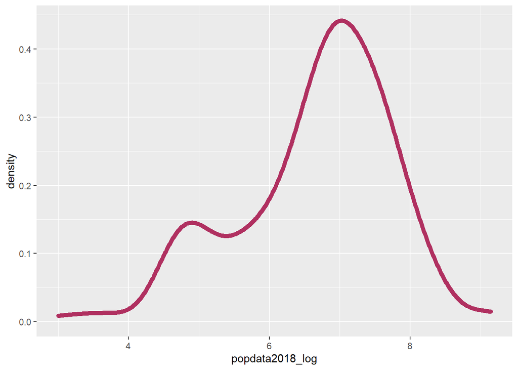

```r
# try the next one:

ggplot(Corona,
       aes(x = popdata2018_log)) +
  geom_density(col='maroon', lwd=2)
```

A plot always should be annotated properly. That is, it $x$- and $y$- axis should be labled properly, and its title should be informative. Here is how we can change the defalut, and often uninformaive, lables to a cleaner and more informative version:

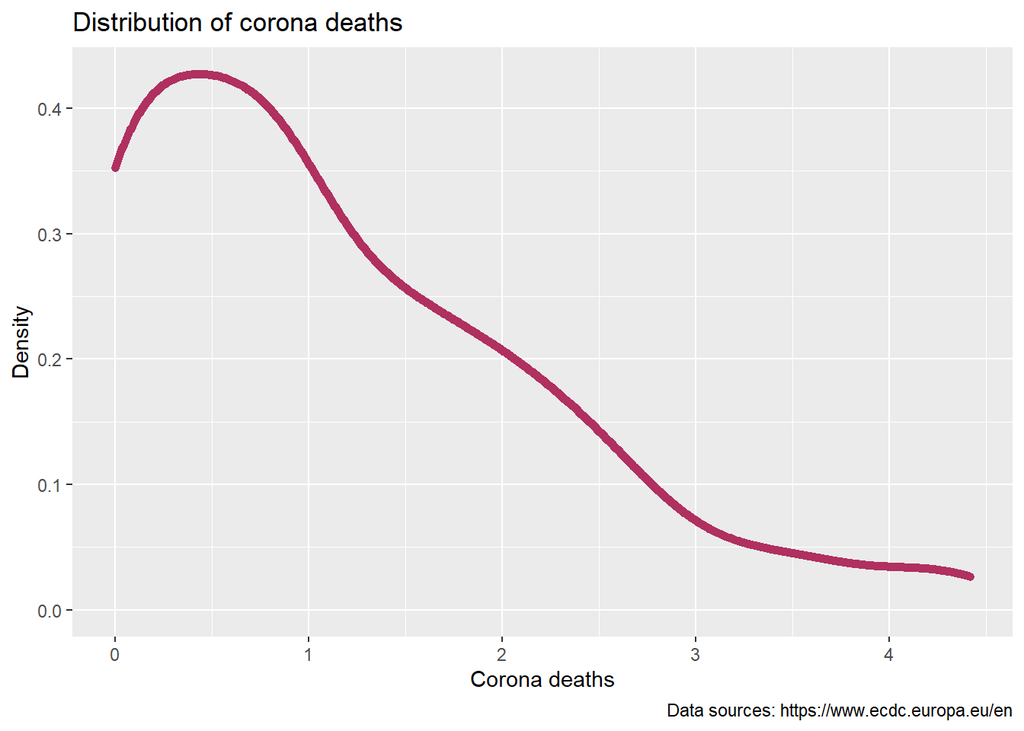

```r
ggplot(Corona,
       aes(x = deaths_log)) +
  geom_density(col='maroon', lwd=2)+
 labs(title = "Distribution of corona deaths",
       #subtitle = "You may need to add subtitles",
       x = "Corona deaths",
       y = "Density",
      caption="Data sources: https://www.ecdc.europa.eu/en")
```

Before running regression models, it is always helpful to check how variables of interes- for example, dependent abd independent variables- are associted. Assume that you want to see how the population size is associated with whether a country has more than 1000 deaths. One option is scatterplot:

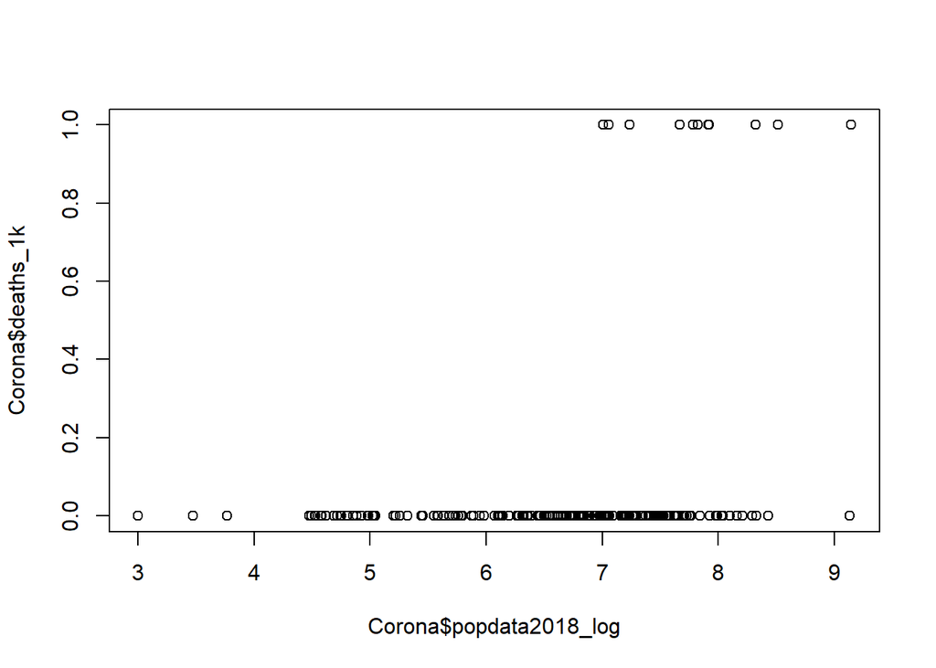

```r
 plot(Corona$popdata2018_log, Corona$deaths_1k)
```

This plot doesn’t look much informative, in such cases with a categorical variable, it is usually better to use the boxplot:

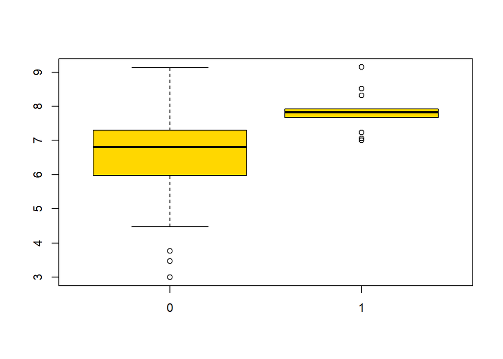

```r
boxplot(Corona$popdata2018_log~Corona$deaths_1k,
        col='gold')
```

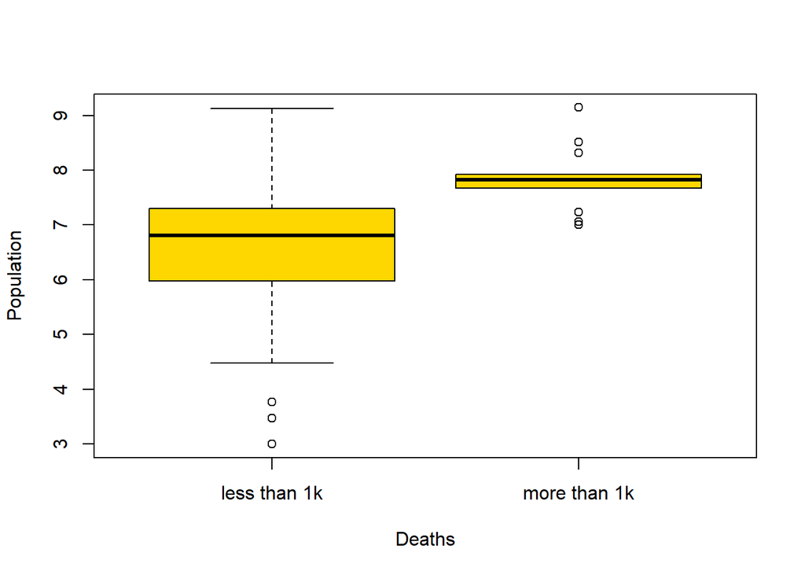

```r
# Make Plots Great Again (MPGA):

boxplot(Corona$popdata2018_log~Corona$deaths_1k,
        col='gold',
        names=c("less than 1k","more than 1k"),
        xlab='Deaths', ylab='Population')
```